# index.Rmd

Anna-Liina Olkinuora

8 maaliskuuta 2017

# Abstract

In this final assignment I try to find a suitable model for modelling alcohol usage. I also perform a principal component analysis on the data that includes alcohol usage and some backgound variables. I find that absences have a positive and statistically significant effect on alcohol usage. Studying time affects alcohol consumption negatively and statistically significantly. Health, age, relationship status, guardian and internet usage don´t have statistically significant effects on alcohol consumption.

# Reasearch question

I examine the effect of absences, health, time used in studying, age, relationship status, guardian and internet usage on alcohol usage. My hypothesis is that absences and age affect positively and statistically significantly on alcohol usage. My another hypothesis is that health, time used in studying and being in a relationship affect negatively and statistically significantly on alcohol usage. I guess that guardian and internet usage have no significant effects on alcohol usage.

# Data

You can see how I have wrangled data here: https://github.com/aolkinuo/IODS-final/blob/master/data/create_alc_final.R

Data is from UCI Machine Learning Repository. It includes information about people´s alcohol consumption and many backgroud variables such as absences, health, time used in studying, age, relationship status, guardian and internet usage. The data was originally in two parts and I combined them using some of the variables. I removed the variables not used in combining from the data. I removed all other variables but alcohol usage, absences, health, time used in studying, age, relationship status, guardian, internet usage and sex from the data. I renamed the variables with Finnish names. I removed the rows that had missing observations. I removed men from the data and removed the sex variable afterwords. I made new numerical versions of the variables relationship status, guardian and internet usage and removed the characterical versions of the variables from the data. I renamed the numerical versions of relationship status, guardian and internet usage with the same names that their characterical versions had.

```r
#Changing the working directory
setwd("C:/Users/Anna-Liina/Documents/IODS-final")

#Reading the data into the memory
alc=read.table("data/alc.txt", sep = ",", header = TRUE)

#Checking out the structure of the data
str(alc)
```

```
## 'data.frame':    198 obs. of  8 variables:
##  $ alk_käyttö: num  1 1 2.5 1 1.5 1 1.5 1 1.5 1.5 ...
##  $ poissaolot: int  5 3 8 1 2 4 1 2 5 8 ...
##  $ terveys   : int  3 3 3 5 5 1 2 4 2 2 ...
##  $ opisk_aika: int  2 2 2 3 2 2 2 3 1 3 ...
##  $ ikä       : int  18 17 15 15 16 17 15 15 16 16 ...
##  $ parisuhde : int  1 1 1 2 1 1 1 1 1 1 ...
##  $ huoltaja  : int  2 1 2 2 1 2 2 1 2 2 ...
##  $ netti     : int  1 2 2 2 1 1 2 2 2 2 ...
```

```r
#Checking the dimension of the data
dim(alc)
```

```
## [1] 198   8
```

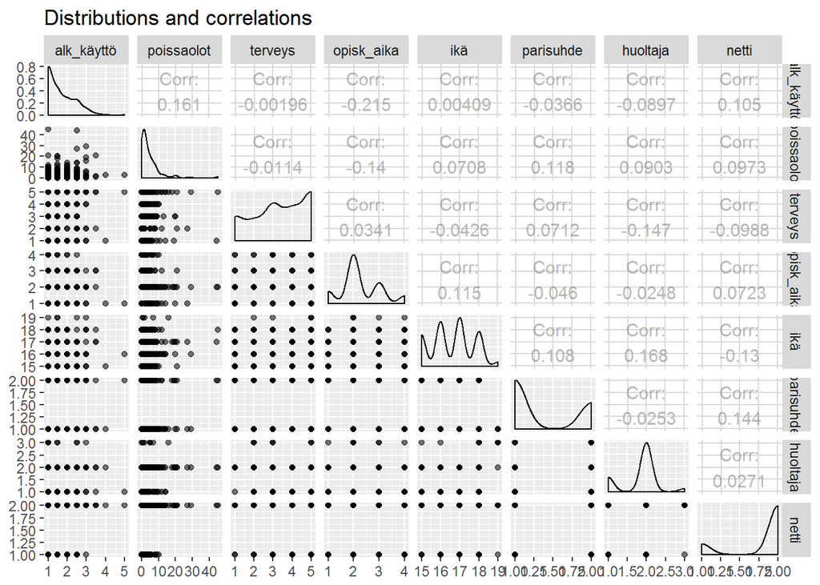

```r
#Drawing a plot with distributions of the variables and their #correlations
library(ggplot2)

library(GGally)

p=ggpairs(alc, mapping = aes(alpha = 0.3), lower = list(combo = wrap("facethist", bins = 20)), title="Distributions and correlations")

p
```

```r
cor(alc)
```

```
##              alk_käyttö  poissaolot      terveys  opisk_aika          ikä
## alk_käyttö  1.000000000  0.16087056 -0.001963377 -0.21540013  0.004094312
## poissaolot  0.160870556  1.00000000 -0.011375590 -0.14015173  0.070780831
## terveys    -0.001963377 -0.01137559  1.000000000  0.03413112 -0.042563576
## opisk_aika -0.215400134 -0.14015173  0.034131124  1.00000000  0.114599804
## ikä         0.004094312  0.07078083 -0.042563576  0.11459980  1.000000000
## parisuhde  -0.036640749  0.11800702  0.071240604 -0.04595393  0.108268398
## huoltaja   -0.089658739  0.09033791 -0.147397492 -0.02481990  0.168227805
## netti       0.105151094  0.09726096 -0.098809784  0.07227258 -0.130471879
##              parisuhde    huoltaja       netti
## alk_käyttö -0.03664075 -0.08965874  0.10515109
## poissaolot  0.11800702  0.09033791  0.09726096
## terveys     0.07124060 -0.14739749 -0.09880978
## opisk_aika -0.04595393 -0.02481990  0.07227258
## ikä         0.10826840  0.16822781 -0.13047188
## parisuhde   1.00000000 -0.02527798  0.14440032
## huoltaja   -0.02527798  1.00000000  0.02714283
## netti       0.14440032  0.02714283  1.00000000
```

# Analysis

First I use ordinary least squares method to see if absences, health, time used in studying, age, relationship status, guardian and internet usage explain alcohol usage significantly. I also want to know how large part of the variation in alcohol usage is due to the variation in other variables. I check if the assumptions of the linear regression model hold. Then I perform a principal component analysis on the data.

```r
m1=lm(alk_käyttö~., data=alc)

summary(m1)
```

```
##
## Call:
## lm(formula = alk_käyttö ~ ., data = alc)
##
## Residuals:
##     Min      1Q  Median      3Q     Max
## -1.2932 -0.5053 -0.2216  0.4772  3.0562
##
## Coefficients:
##              Estimate Std. Error t value Pr(>|t|)
## (Intercept)  1.284460   0.869257   1.478  0.14116
## poissaolot   0.015422   0.008151   1.892  0.06000 .
## terveys      0.006201   0.036496   0.170  0.86527
## opisk_aika  -0.203720   0.064967  -3.136  0.00199 **
## ikä          0.046320   0.048462   0.956  0.34038
## parisuhde   -0.144261   0.109545  -1.317  0.18945
## huoltaja    -0.187279   0.107923  -1.735  0.08431 .
## netti        0.260240   0.138128   1.884  0.06109 .
## ---
## Signif. codes:  0 '***' 0.001 '**' 0.01 '*' 0.05 '.' 0.1 ' ' 1
##
## Residual standard error: 0.7116 on 190 degrees of freedom
## Multiple R-squared:  0.09835,    Adjusted R-squared:  0.06513
## F-statistic: 2.961 on 7 and 190 DF,  p-value: 0.005733
```

The stars and dots in the picture indicate the statistical significance of the explanatory variables. Behind the stars and dots is a statistical test where is tested whether the null hypothesis about whether the parameter that is related to the explanatory variable is zero can be rejected. The null hypothesis about whether the parameters related to the variables absences, studying time, guardian and internet usage are zero can be rejected with significance levels 0.1, 0.01, 0.1 and 0.1, respectively. That means that the parameters related to the variables absences, studying time, guardian and internet usage that is their effects on alcohol usage are significant. The null hypothesis about whether the parameters of the variables health, age and relationship status are zeros cannot be rejected. Their effects to alcohol usage are hence not significant. I next remove health, age and relationship status from the model due to their parameter estimates bad significance. I use ordinary least squares to estimate a new model without them.

```r
m2=lm(alk_käyttö~poissaolot+opisk_aika+huoltaja+netti, data=alc)

summary(m2)
```

```
##
## Call:
## lm(formula = alk_käyttö ~ poissaolot + opisk_aika + huoltaja +
##     netti, data = alc)
##
## Residuals:
##     Min      1Q  Median      3Q     Max
## -1.2898 -0.5024 -0.2401  0.4759  2.9857
##
## Coefficients:
##              Estimate Std. Error t value Pr(>|t|)
## (Intercept)  1.901464   0.335171   5.673 5.07e-08 ***
## poissaolot   0.015065   0.008069   1.867  0.06342 .
## opisk_aika  -0.190583   0.063965  -2.979  0.00326 **
## huoltaja    -0.166703   0.105020  -1.587  0.11407
## netti        0.212484   0.133514   1.591  0.11314
## ---
## Signif. codes:  0 '***' 0.001 '**' 0.01 '*' 0.05 '.' 0.1 ' ' 1
##
## Residual standard error: 0.7104 on 193 degrees of freedom
## Multiple R-squared:  0.08725,    Adjusted R-squared:  0.06833
## F-statistic: 4.612 on 4 and 193 DF,  p-value: 0.001406
```

Now I see that intercept and the parameters of the variables absences and atudying time arre statistically significant with significance levels 0.001, 0.1 and 0.01, respectively. Parameters of the variables guardian and internet usage are no more significant. I also see that when absences raises by one, alcohol usage raises by 0.015. When studying time raises by one, alcohol usage decreases by 0.191. When all the explanatory variables are zero, alcohol usage has the value 1.901. Studying time, guardian and internet usage are cathegorical variables and they have comparable groups that are included in the intercept. For example guardian being a father and no internet connection are in the intercept. The parameter value of guardian means that guardian being a mother decreases alcohol usage by 0.167. Parameter value of internet usage means that having an internet raises alcohol usage by 0.212. Multiple R-squared and adjusted R-squared are coefficients of determination of the model. Coefficient of determination tells how much the model that is the explanatory variables explain of the variation in the dependent variable and it gets values between zero and one that is zero and hundred in per cents. In this model absences, studying time, guardian and internet usage explain 8.7 per cents of the variation in alcohol usage. Hence the model is not performing very well. Adjusted R-squared gets always a value smaller than multiple R-squared because it takes the amount of explanatory variables into account. It is more accurate meter of the performance of the model than multiple R-squared. Adding a new variable into a model is likely to increase multiple R-squared and lower adjusted R-squared. In this model the adjusted R-squared is 6.8 per cents. From the results of the regression analysis I notice that my hypothesis was partly wrong. I was right when I guessed that absences have statistically significant and positive effect on alcohol usage. I was also right guessing that studying time has a significant and negative effect on alcohol usage and that the effects of guardian and internet usage are not significant. I didn´t know that the effects of health, age and relationship status have non-significant effects on alcohol usage.

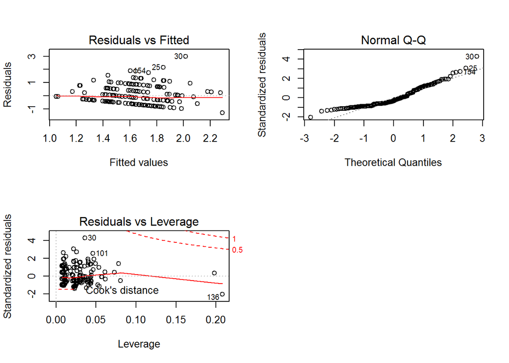

```r
par(mfrow = c(2,2))
plot(m2, which = c(1,2,5))
```

```r
#Performing the principal component analysis (with the SVD method)
pca_alc <- prcomp(alc)

# create and print out a summary of pca_human
s <- summary(pca_alc)
s
```

```
## Importance of components:
##                           PC1     PC2     PC3     PC4     PC5    PC6
## Standard deviation     6.3992 1.42425 1.10787 0.82835 0.68017 0.4841
## Proportion of Variance 0.8917 0.04417 0.02673 0.01494 0.01007 0.0051
## Cumulative Proportion  0.8917 0.93588 0.96261 0.97755 0.98763 0.9927
##                           PC7     PC8
## Standard deviation     0.4598 0.35006
## Proportion of Variance 0.0046 0.00267
## Cumulative Proportion  0.9973 1.00000
```

```r
# rounded percentages of variance captured by each PC
pca_pr <- round(100*s$importance[2,], digits = 1)

# print out the percentages of variance
pca_pr
```

```
##  PC1  PC2  PC3  PC4  PC5  PC6  PC7  PC8
## 89.2  4.4  2.7  1.5  1.0  0.5  0.5  0.3
```

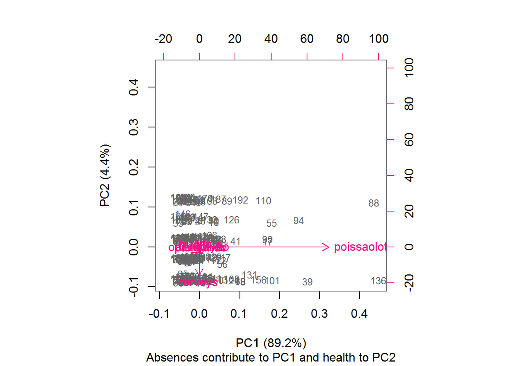

```r
# create object pc_lab to be used as axis labels
pc_lab <- paste0(names(pca_pr), " (", pca_pr, "%)")

# draw a biplot
biplot(pca_alc, cex = c(0.8, 1), col = c("grey40", "deeppink2"), xlab = pc_lab[1], ylab = pc_lab[2], sub="Absences contribute to PC1 and health to PC2")
```

I performed a principal component analysis on the data. From a biplot of the two first principal components we see that health and absences don´t correlate a lot as the angle between the arrows representing them is large. Absences contribute to the first principal component as the arrow repserenting absences is pointing at the same direction as x-axis. Health contributes to the second principal component as the arrow representing is in line with the y-axis. The lenght of the arrows describes the stardard deviation of the variables or features.

# Conclusion